# Applying FAIR4RS to your projects

Sylvia Whittle

## Our project in March 2022

- On GitHub
- Two developers
- Changes made by one would break the other’s code
- Difficult to install (sometimes impossible!)
- Deprecated python 2.7
- To change a variable, you had to open the code

## What did we do?

## Updated GitHub repository: process

- Added a welcoming README file
- Ensured the licensing was clear
- Added a code of conduct
- Added a contributing guide

[figure not shown]

topostats_github

## Updating to python 3.X: process

- Started from scratch in Python 3.X
- Ditched some dependencies, updated others
- Wrote our own code to replace some of the dependencies that were no longer compatible

#### Effort: 4 months

## Updating to python 3.X: benefits

- Code was more stable
- More people could use it
- Up-to-date python features and libraries
- Online tutorials & examples were relevant

## Improving installation: process

- Removed the need to install dependencies separately by writing our own code to replace them
- Turned the project into a python 3.X package
- Published the code to PyPI so it can be installed by anyone

```bash
pip install topostats
```

[figure not shown]

pypi

#### Effort: 1 day once the code was ready

## Improving installation: benefits

- Friendlier installation means more users
- Onboarding is so much faster
- Now works on all computers!
- Time is saved with every new user, and new member of our research team

## Configuration file: process

- Removed all hard-coded parameters from the code
- Created a configuration file in YAML format
- Wrote code to load the configuration file
- Wrote code to check that the configuration file is valid and makes sense

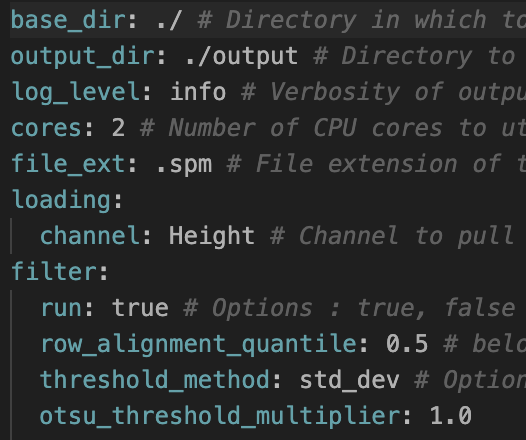

config_file

#### Effort: 1 week for basic functionality

## Configuration file: benefits

- Easy way to group parameters into one place
- Users don’t have to open the code
- Configurations saved with the output files for reproducibility

## Documentation: process

- Wrote a README file to explain the project
- Wrote documentation in the form of docstrings for every function, class and file
- Wrote a tutorial to help users get started
- Set up automatic documentation generation and hosting using Sphinx (involved, but worth it!)

#### Effort: 1 week

## Documentation: benefits

- Each function, class and file is explained for developers and users
- Documentation available online as a website
- Automatically generated & updated (no effort once set up!)
- Eliminates the time I spend wondering what a function I wrote 6 months ago does!

## Code linting: process

- Installed an automatic formatter (black for python)
- Ran the formatter on the code, which automatically re-structures the code to match best practices

#### Effort: 1 hour

- Installed a linter (flake8 for python)
- Ran the linter on the code, which checks that the code is written in a way that adheres to best practices
- Fix the many errors and warnings

### Effort: 1 month

## Code linting: benefits

- Everyone speaks the same coding “dialect”
- Code is easier to read and understand
- Bugs are harder to introduce when following best practices
- Reinforces good coding habits

## Versioning: process

- Set up versioning on GitHub
- Set up automatic versioning on PyPI
- Set up automatic documentation versioning & generation using Sphinx

#### Effort: 1 day for basic functionality

## Versioning: benefits

- Development versions are on GitHub
- Stable versions are released to PyPI
- Documentation is versioned too!

## Testing: process

- Wrote tests for every function, class and file
- Set up automatic testing on GitHub using GitHub Actions

#### Effort: Months, ongoing

## Testing: benefits

- Difficult to begin with
- Adds time to development
- More than makes up for it when writing new features

## Our project in 2023

- 250 ish downloads per month on PyPI
- Collaborators around the world
- 70% test coverage
- 95% ish documentation coverage

## Reassurances

- You don’t have to do it all at once
- You don’t have to do it all yourself
- You don’t have to do it perfectly
- Every little helps